# plotnine_test

## What have the romans has *plotnine* ever give us in Python?

To get started I found [this tutorial](https://realpython.com/ggplot-python/) super useful.

Here is a more comprehensive, [super-useful tutorial](https://datascienceworkshops.com/blog/plotnine-grammar-of-graphics-for-python/) (by Jeroen Janssens, author of plotnine) on the library especially for those who already worked with ggplot.

Also have a look at the [graph gallery](https://r-graph-gallery.com/ggplot2-package.html) - a real eyecandy!

```python
# import the python equivalent to R's ggplot: plotnine  and our dataset:
from plotnine.data import diamonds
```

```python
# inspect data
diamonds.info
```

```
<bound method DataFrame.info of        carat        cut color clarity  depth  table  price     x     y     z
0       0.23      Ideal     E     SI2   61.5   55.0    326  3.95  3.98  2.43
1       0.21    Premium     E     SI1   59.8   61.0    326  3.89  3.84  2.31
2       0.23       Good     E     VS1   56.9   65.0    327  4.05  4.07  2.31
3       0.29    Premium     I     VS2   62.4   58.0    334  4.20  4.23  2.63
4       0.31       Good     J     SI2   63.3   58.0    335  4.34  4.35  2.75
...      ...        ...   ...     ...    ...    ...    ...   ...   ...   ...
53935   0.72      Ideal     D     SI1   60.8   57.0   2757  5.75  5.76  3.50
53936   0.72       Good     D     SI1   63.1   55.0   2757  5.69  5.75  3.61
53937   0.70  Very Good     D     SI1   62.8   60.0   2757  5.66  5.68  3.56
53938   0.86    Premium     H     SI2   61.0   58.0   2757  6.15  6.12  3.74
53939   0.75      Ideal     D     SI2   62.2   55.0   2757  5.83  5.87  3.64

[53940 rows x 10 columns]>
```

Our database contains info about over 50,000 diamonds, of which we'll use cut, carat, color, clarity and price for plotting. You can find [further information](https://rpubs.com/GinaMoreno__/course1_4) on the DB.

### Let's try some basic plotting, with easy coloring

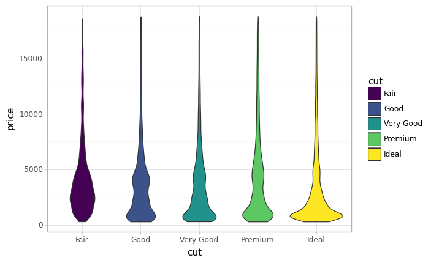

```python
# import necessary functions to build the following plot
from plotnine import ggplot, aes, geom_violin, theme_light

(
    ggplot(diamonds)  # What data to use
    + aes(x="cut", y= "price", fill = "cut")  # What variable to use, including the variable for fillcolor
    + geom_violin()  # Geometric object to use for drawing
    + theme_light() # to make it clearer

)
```

The lesson: most diamonds are actually cheap!

### Histogram for count values, with flipping for more clarity and a bonus theme

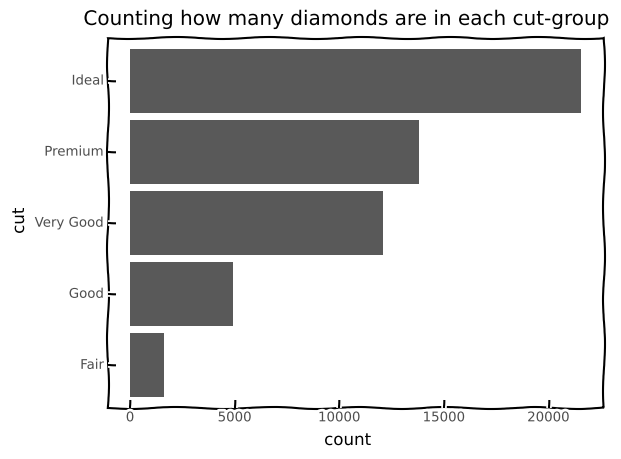

```python
from plotnine import ggplot, aes, geom_bar, coord_flip, theme_xkcd, labs

(
ggplot(diamonds)
    + aes(x="cut")
    + geom_bar()
    + coord_flip()
    + labs(title = "Counting how many diamonds are in each cut-group")
    + theme_xkcd()
)
```

### Boxplots and violinplots: the most informative plot to inspect the distribution of the data

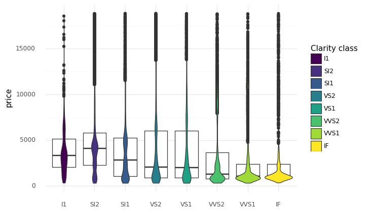

```python
from plotnine import ggplot, aes, stat_bin, geom_boxplot, theme_minimal, geom_violin

(
ggplot(diamonds)
    + aes(x="clarity", y= "price")
    + geom_boxplot()
    + geom_violin(aes(fill="clarity"))
    + labs(fill="Clarity class",
          x = "")
    + theme_minimal()
)
```

## Clarity and cut: relationship with price?

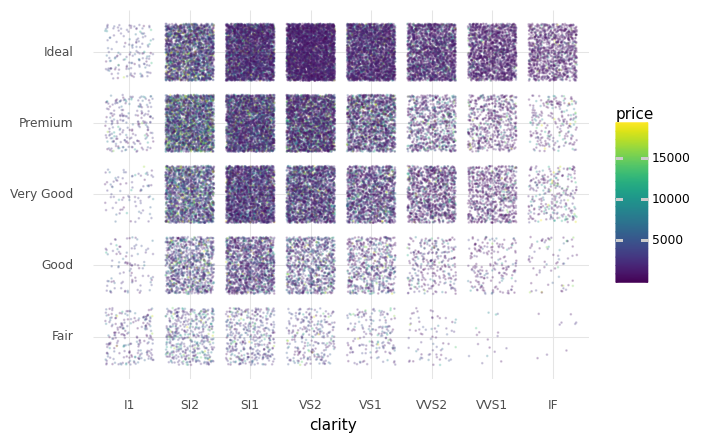

```python
from plotnine import ggplot, aes, labs, geom_jitter, theme_minimal

(
    ggplot(diamonds)
    + aes(x="clarity", y="cut", color="price")
    + labs(title="", y="")
    + geom_jitter(alpha = 0.2, size = 0.1)
    + theme_minimal()
)
```

## Faceting on 2 categorical variables: clarity and cut to see their relationship with a continuous variable (price)

[figure not shown]

```python
from plotnine import ggplot, aes, facet_grid, labs, geom_point, theme_minimal, theme, element_text

(
    ggplot(diamonds)
    + facet_grid(facets="cut~color")
    + aes(x="clarity", y="price", color = "price")
    + geom_point()
    + labs(
        x="Clarity",
        y="Price",
        title="Price of the diamond, given cut and clarity",
        )
    + theme_minimal()
    + theme(axis_text_x=element_text(rotation=90, hjust=1)) # rotate x labels to improve readibility

)
```

### Finally, my favourite visualisation of this dataset, turboed with prediction lines

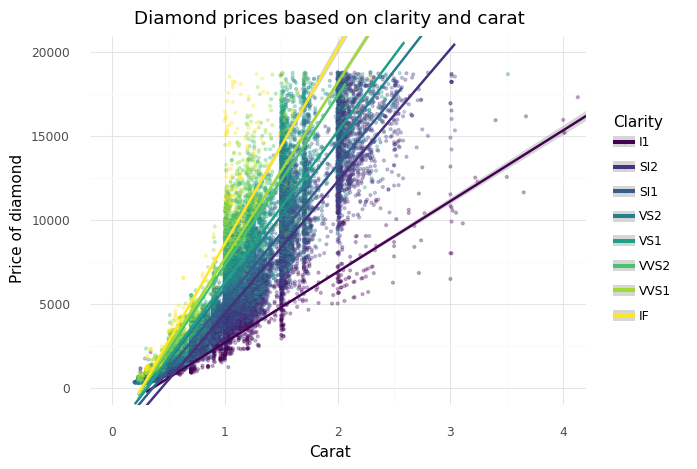

```python
from plotnine import ggplot, aes, geom_point, geom_smooth, theme_minimal, coord_cartesian

(
ggplot(diamonds)
    + aes("carat", "price", color = "clarity")
    + geom_point(alpha = 0.3, size = 0.7) # make points opaque to better account for overlap
    + geom_smooth(stat="smooth") # GLM-based prediction line with 95% CI
    + labs(
        title = "Diamond prices based on clarity and carat",
        x = "Carat",
        y = "Price of diamond",
        color = "Clarity")
    + coord_cartesian(xlim = [0, 4], ylim = [0, 20000])
    + theme_minimal()

)
```

The clarity of the diamond seems to be a strong predictor of the price, with clear (IF, "internally flawless") diamonds being the most expensive. Note the uneven distribution of carat, which can be tricky in ML models (floor effect around integers and halves).

And if you wanted to see the above plot but separately by cut:

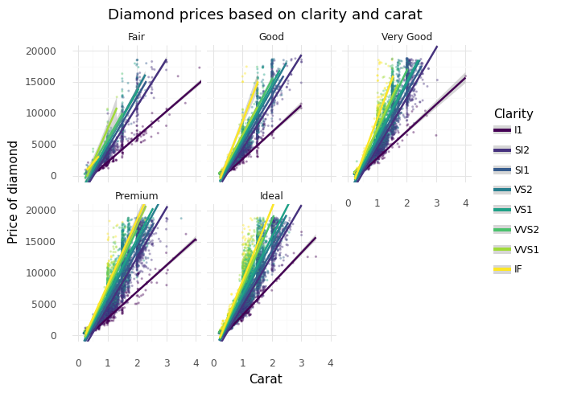

```python
from plotnine import ggplot, aes, geom_point, geom_smooth, theme_minimal, coord_cartesian, facet_wrap

(
ggplot(diamonds)
    + aes("carat", "price", color = "clarity")
    + geom_point(alpha = 0.3, size = 0.3) # make points opaque to better account for overlap
    + geom_smooth(stat="smooth") # GLM-based prediction line with 95% CI. Interestingly, plotnine appears to provide an "overall" prediction line (ggplot provides a point-by-point, curvy solution)
    + labs(
        title = "Diamond prices based on clarity and carat",
        x = "Carat",
        y = "Price of diamond",
        color = "Clarity")
    + coord_cartesian(xlim = [0, 4], ylim = [0, 20000])
    + facet_wrap("cut")
    + theme_minimal()

)
```